# Introduction to R Markdown

Byron C. Jaeger[^1]

## Subsections

The pound symbol lets you create new sections and subsections in your markdown document. A single pound creates a new section, double pound creates a subsection, triple pound creates sub-subsection, and so on.

# Paged data

The `df_print: paged` option is a wonderful option. It allows you to print data in an interactive way

```r
iris
```

| Sepal.Length | Sepal.Width | Petal.Length | Petal.Width | Species |
| --- | --- | --- | --- | --- |
| 5.1 | 3.5 | 1.4 | 0.2 | setosa |
| 4.9 | 3.0 | 1.4 | 0.2 | setosa |
| 4.7 | 3.2 | 1.3 | 0.2 | setosa |
| 4.6 | 3.1 | 1.5 | 0.2 | setosa |
| 5.0 | 3.6 | 1.4 | 0.2 | setosa |
| 5.4 | 3.9 | 1.7 | 0.4 | setosa |
| 4.6 | 3.4 | 1.4 | 0.3 | setosa |
| 5.0 | 3.4 | 1.5 | 0.2 | setosa |
| 4.4 | 2.9 | 1.4 | 0.2 | setosa |
| 4.9 | 3.1 | 1.5 | 0.1 | setosa |

[output cut: 140 more lines]

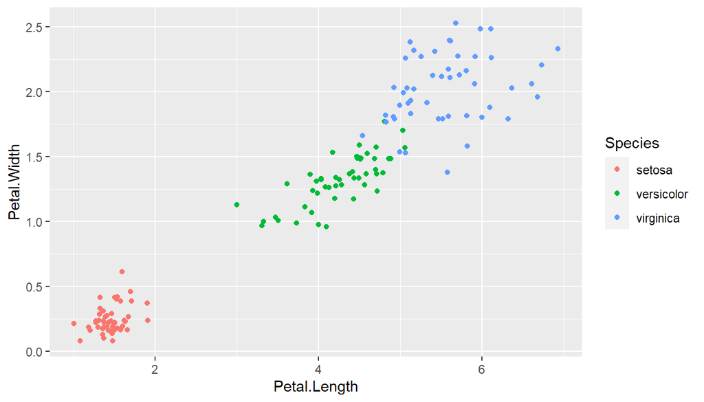

```r
ggplot(iris) +
  aes(x = Petal.Length,  y = Petal.Width, col = Species) +
  geom_point(position = 'jitter')
```

# Themes

Theme specifies the overall look of an html document. Valid theme values are:

- default
- cerulean
- journal
- flatly
- darkly
- readable
- spacelab
- united
- cosmo
- lumen
- paper
- sandstone
- simplex
- yeti

Try replacing the word ‘united’ in the YAML header with some of these themes. Find something you like! You will spend a lot of time staring at these documents, so it’s worth investing some time to make them look nice.

## Code highlights

highlight specifies the syntax highlighting style. Supported styles include

- default
- tango
- pygments
- kate
- monochrome
- espresso
- zenburn
- haddock
- breezedark
- textmate

Pass null to prevent syntax highlighting.

# Tabulate with `gt`

The **gt** package is all about making it simple to produce nice-looking display tables. Display tables? Well yes, we are trying to distinguish between data tables (e.g., tibbles, `data.frame`s, etc.) and those tables you’d find in a web page, a journal article, or in a magazine. Such tables can likewise be called presentation tables, summary tables, or just tables really.

We can think of display tables as output only, where we’d not want to use them as input ever again. Other features include annotations, table element styling, and text transformations that serve to communicate the subject matter more clearly.

## Basics of `gt`

Let’s use a less common dataset that is available in the R **datasets** package: `islands`. It’s actually not a data frame but a named vector. That’s okay though, the code below converts it into a tibble (we’ll learn more about these later):

```r
islands_tbl <- enframe(islands, value = 'size') %>%
  dplyr::arrange(desc(size)) %>%
  dplyr::slice(1:10)

# Display the table
islands_tbl
```

| name | size |
| --- | --- |
| Asia | 16988 |
| Africa | 11506 |
| North America | 9390 |
| South America | 6795 |
| Antarctica | 5500 |
| Europe | 3745 |
| Australia | 2968 |
| Greenland | 840 |
| New Guinea | 306 |
| Borneo | 280 |

Given that `islands_tbl` is a tibble, we now have a suitable input for **gt**.

The main entry point into the **gt** API is the `gt()` function. If we pass `islands_tbl` to the *function* `gt()`, we’ll get a **gt Table** as output. As an aside, we could have easily used a data frame instead as valid **Table Data** for **gt**.

```r
# Create a display table showing ten of
# the largest islands in the world
gt_tbl_1 <- gt(data = islands_tbl)

# Show the gt Table
gt_tbl_1
```

| name | size |
| --- | --- |
| Asia | 16988 |
| Africa | 11506 |
| North America | 9390 |
| South America | 6795 |
| Antarctica | 5500 |
| Europe | 3745 |
| Australia | 2968 |
| Greenland | 840 |
| New Guinea | 306 |
| Borneo | 280 |

That doesn’t look too bad. Sure, it’s basic but we really didn’t really ask for much. We did receive a proper table with column labels and the data. Also, that default striping is a nice touch. Oftentimes however, you’ll want a bit more: a **Table header**, a **Stub**, and sometimes *footnotes* and *source notes* in the **Table Footer** part.

## Adding parts

The **gt** package makes it relatively easy to add parts so that the resulting **gt Table** better conveys the information you want to present. These table parts work well together and there the possible variations in arrangement can handle most tabular presentation needs. The previous **gt Table** demonstrated had only two parts, the **Column Labels** and the **Table Body**. The next few examples will show all of the other table parts that are available.

This is the way the main parts of a table (and their subparts) fit together:

[figure not shown]

The parts (roughly from top to bottom) are:

- the **Table Header** (optional; with a **title** and possibly a **subtitle**)
- the **Stub** and the **Stub Head** (optional; contains *row labels*, optionally within *row groups* having *row group labels* and possibly *summary labels* when a summary is present)
- the **Column Labels** (contains *column labels*, optionally under *spanner column labels*)
- the **Table Body** (contains *columns* and *rows* of *cells*)
- the **Table Footer** (optional; possibly with **footnotes** and **source notes**)

The way that we add parts like the **Table Header** and *footnotes* in the **Table Footer** is to use the `tab_*()` family of functions. A **Table Header** is easy to add so let’s see how the previous table looks with a **title** and a **subtitle**. We can add this part using the `tab_header()` function:

```r
# Make a display table with the `islands_tbl`
# table; put a heading just above the column labels
gt_tbl_2 <- tab_header(
  data = gt_tbl_1,
  title = "Large Landmasses of the World",
  subtitle = "The top ten largest are presented"
)

# Show the gt Table
gt_tbl_2
```

Large Landmasses of the World

The top ten largest are presented

| name | size |
| --- | --- |
| Asia | 16988 |
| Africa | 11506 |
| North America | 9390 |
| South America | 6795 |
| Antarctica | 5500 |
| Europe | 3745 |
| Australia | 2968 |
| Greenland | 840 |
| New Guinea | 306 |
| Borneo | 280 |

The **Header** table part provides an opportunity to describe the data that’s presented. The `subtitle`, which functions as a subtitle, is an optional part of the **Header**. We may also style the `title` and `subtitle` using Markdown! We do this by wrapping the values passed to `title` or `subtitle` with the `md()` function. Here is an example:

```r
# Use markdown for the heading's `title` and `subtitle` to
# add bold and italicized characters

gt_tbl_3 <- tab_header(
  data = gt_tbl_1,
  title = md("__Large Landmasses of the World__"),
  subtitle = md("The _top ten_ largest are presented")
)

# Show the gt Table
gt_tbl_3
```

**Large Landmasses of the World**

The *top ten* largest are presented

| name | size |
| --- | --- |
| Asia | 16988 |
| Africa | 11506 |
| North America | 9390 |
| South America | 6795 |
| Antarctica | 5500 |
| Europe | 3745 |
| Australia | 2968 |
| Greenland | 840 |
| New Guinea | 306 |
| Borneo | 280 |

A **source note** can be added to the table’s **footer** through use of the `tab_source_note()` function. It works in the same way as `tab_header()` (it also allows for Markdown inputs) except it can be called multiple times—each invocation results in the addition of a source note.

```r
# Display the `islands_tbl` data with a heading and
# two source notes

gt_tbl_4 <- tab_source_note(
  data = gt_tbl_3,
  source_note = "Source: The World Almanac and Book of Facts, 1975, page 406."
)

gt_tbl_5 <- tab_source_note(
  data = gt_tbl_4,
  source_note = md("McNeil, D.R. (1977) _Interactive Data Analysis_. Wiley.")
)

# Show the gt Table
gt_tbl_5
```

**Large Landmasses of the World**

The *top ten* largest are presented

| name | size |
| --- | --- |
| Asia | 16988 |
| Africa | 11506 |
| North America | 9390 |
| South America | 6795 |
| Antarctica | 5500 |
| Europe | 3745 |
| Australia | 2968 |
| Greenland | 840 |
| New Guinea | 306 |
| Borneo | 280 |

Source: The World Almanac and Book of Facts, 1975, page 406.  
McNeil, D.R. (1977) *Interactive Data Analysis*. Wiley.

## The stub

The **Stub** is the area to the left in a table that contains *row labels*, and may contain *row group labels*, and *summary labels*. Those subparts can be grouped in a sequence of *row groups*. The **Stub Head** provides a location for a label that describes the **Stub**. The **Stub** is optional since there are cases where a **Stub** wouldn’t be useful (e.g., the display tables presented above were just fine without a **Stub**).

An easy way to generate a **Stub** part is by specifying a stub column in the `gt()` function with the `rowname_col` argument. Alternatively, we can have an input dataset with a column named `rowname`—this magic column will signal to **gt** that that column should be used as the stub, making *row labels*. Let’s add a stub with our `islands_tbl` dataset by modifying the call to `gt()`:

```r
# Create a gt table showing ten of the
# largest islands in the world; this
# time with a stub
gt_tbl_1 <- gt(islands_tbl, rowname_col = "name")

# Show the gt Table
gt_tbl_1
```

|  | size |
| --- | --- |
| Asia | 16988 |
| Africa | 11506 |
| North America | 9390 |
| South America | 6795 |
| Antarctica | 5500 |
| Europe | 3745 |
| Australia | 2968 |
| Greenland | 840 |
| New Guinea | 306 |
| Borneo | 280 |

Notice that the landmass names are off the the left in an unstriped area? That’s the **stub**. We can apply what’s known as a **stubhead label**. This label can be added with the `tab_stubhead()` function:

```r
# Generate a simple table with a stub
# and add a stubhead label
gt_tbl_1 <- tab_stubhead(data = gt_tbl_1, label = "landmass")

# Show the gt Table
gt_tbl_1
```

| landmass | size |
| --- | --- |
| Asia | 16988 |
| Africa | 11506 |
| North America | 9390 |
| South America | 6795 |
| Antarctica | 5500 |
| Europe | 3745 |
| Australia | 2968 |
| Greenland | 840 |
| New Guinea | 306 |
| Borneo | 280 |

A very important thing to note here is that the table now has one column. Before, when there was no **stub**, two columns were present (with **column labels** `name` and `size`) but now column number `1` (the only column) is `size`.

```r
# Display the `islands_tbl` data with a stub,
# a heading, source notes, and footnotes

# Make a display table with the `islands_tbl`
# table; put a heading just above the column labels
gt_tbl_2 <- tab_header(
  data = gt_tbl_1,
  title = md("__Large Landmasses of the World__"),
  subtitle = md("The _top ten_ largest are presented")
)

gt_tbl_3 <- tab_source_note(
  data = gt_tbl_2,
  source_note = "Source: The World Almanac and Book of Facts, 1975, page 406."
)

gt_tbl_4 <- tab_source_note(
  data = gt_tbl_3,
  source_note = md("McNeil, D.R. (1977) _Interactive Data Analysis_. Wiley.")
)


# Show the gt Table
gt_tbl_4
```

**Large Landmasses of the World**

The *top ten* largest are presented

| landmass | size |
| --- | --- |
| Asia | 16988 |
| Africa | 11506 |
| North America | 9390 |
| South America | 6795 |
| Antarctica | 5500 |
| Europe | 3745 |
| Australia | 2968 |
| Greenland | 840 |
| New Guinea | 306 |
| Borneo | 280 |

Source: The World Almanac and Book of Facts, 1975, page 406.  
McNeil, D.R. (1977) *Interactive Data Analysis*. Wiley.

```r
# Add a column to islands_tbl
islands_tbl$group <- c(
  "Continents",
  "Continents",
  "Continents",
  "Continents",
  "Continents",
  "Continents",
  "Other",
  "Other",
  "Other",
  "Other"
)

gt_tbl_1 <- gt(islands_tbl, rowname_col = "name", groupname_col = 'group')
gt_tbl_2 <- tab_stubhead(data = gt_tbl_1, label = "landmass")

gt_tbl_3 <- tab_header(
  data = gt_tbl_2,
  title = md("__Large Landmasses of the World__"),
  subtitle = md("The _top ten_ largest are presented")
)

gt_tbl_4 <- tab_source_note(
  data = gt_tbl_3,
  source_note = "Source: The World Almanac and Book of Facts, 1975, page 406."
)

gt_tbl_5 <- tab_source_note(
  data = gt_tbl_4,
  source_note = md("McNeil, D.R. (1977) _Interactive Data Analysis_. Wiley.")
)

# Show the gt Table
gt_tbl_5
```

**Large Landmasses of the World**

The *top ten* largest are presented

| landmass | size |
| --- | --- |
| Continents |  |
| Asia | 16988 |
| Africa | 11506 |
| North America | 9390 |
| South America | 6795 |
| Antarctica | 5500 |
| Europe | 3745 |
| Other |  |
| Australia | 2968 |
| Greenland | 840 |
| New Guinea | 306 |
| Borneo | 280 |

Source: The World Almanac and Book of Facts, 1975, page 406.  
McNeil, D.R. (1977) *Interactive Data Analysis*. Wiley.

Having groups of rows in *row groups* is a great way to present information - let’s make it even cleaner. The `tab_style()` function lets you access and modify any conceivable part of your table. In this example, we’ll access the rows that describe groups and then we’ll set their text to be **bold**.

```r
gt_tbl_6 <- tab_style(
  data = gt_tbl_5,
  locations = cells_row_groups(),
  style = cell_text(weight = 'bold')
)

gt_tbl_6
```

**Large Landmasses of the World**

The *top ten* largest are presented

| landmass | size |
| --- | --- |
| Continents |  |
| Asia | 16988 |
| Africa | 11506 |
| North America | 9390 |
| South America | 6795 |
| Antarctica | 5500 |
| Europe | 3745 |
| Other |  |
| Australia | 2968 |
| Greenland | 840 |
| New Guinea | 306 |
| Borneo | 280 |

Source: The World Almanac and Book of Facts, 1975, page 406.  
McNeil, D.R. (1977) *Interactive Data Analysis*. Wiley.

We will circle back to grouping rows when we have learned about `group_by` in the `dplyr` package. We will also talk about including data summaries particular to each group is a natural extension of this idea. This process of adding summary rows with *summary labels* is covered [here](https://gt.rstudio.com/articles/creating-summary-lines.html) if you are eager to learn more.

## Column labels

The table’s **Column Labels** part contains, at a minimum, columns and their *column labels*. The last example had a single column: `size`. Let’s give it a better label.

```r
gt_tbl_7 <- cols_label(
  data = gt_tbl_6,
  size = "Area in square miles"
)

# Show the gt Table
gt_tbl_7
```

**Large Landmasses of the World**

The *top ten* largest are presented

| landmass | Area in square miles |
| --- | --- |
| Continents |  |
| Asia | 16988 |
| Africa | 11506 |
| North America | 9390 |
| South America | 6795 |
| Antarctica | 5500 |
| Europe | 3745 |
| Other |  |
| Australia | 2968 |
| Greenland | 840 |
| New Guinea | 306 |
| Borneo | 280 |

Source: The World Almanac and Book of Facts, 1975, page 406.  
McNeil, D.R. (1977) *Interactive Data Analysis*. Wiley.

If you have some experience with html code, you can apply the `html` function to format your labels:

```r
gt_tbl_7 <- cols_label(
  data = gt_tbl_6,
  size = html("Area, miles<sup>2</sup>")
)

# Show the gt Table
gt_tbl_7
```

**Large Landmasses of the World**

The *top ten* largest are presented

| landmass | Area, miles<sup>2</sup> |
| --- | --- |
| Continents |  |
| Asia | 16988 |
| Africa | 11506 |
| North America | 9390 |
| South America | 6795 |
| Antarctica | 5500 |
| Europe | 3745 |
| Other |  |
| Australia | 2968 |
| Greenland | 840 |
| New Guinea | 306 |
| Borneo | 280 |

Source: The World Almanac and Book of Facts, 1975, page 406.  
McNeil, D.R. (1977) *Interactive Data Analysis*. Wiley.

## Format values

The last thing we’ll do to finish this table is format values in a specific column.

```r
fmt_number(
  data = gt_tbl_7,
  columns = 'size',
  sep_mark = ',',
  decimals = 0
)
```

**Large Landmasses of the World**

The *top ten* largest are presented

| landmass | Area, miles<sup>2</sup> |
| --- | --- |
| Continents |  |
| Asia | 16,988 |
| Africa | 11,506 |
| North America | 9,390 |
| South America | 6,795 |
| Antarctica | 5,500 |
| Europe | 3,745 |
| Other |  |
| Australia | 2,968 |
| Greenland | 840 |
| New Guinea | 306 |
| Borneo | 280 |

Source: The World Almanac and Book of Facts, 1975, page 406.  
McNeil, D.R. (1977) *Interactive Data Analysis*. Wiley.

## But *why*?

Clearly, this is not as straightforward as writing our numbers in a Microsoft Word document. In fact, you probably could have completed 3 tables in Microsoft Word in the amount of time it took me to explain how this code works. So, why bother?

*Agility* and *Accuracy*.

- You will be asked to re-do analyses over and over.
- In some cases, the tables will be very thorough and tedious.
- If you learn this now, you can *automate* your analysis so that the tables you make are self-populated.
  - No more copying and pasting your numbers
  - No more errors from copying and pasting numbers to the incorrect place!
- You will also feel like a programming wizard *every time* your tables can be updated in an automated way.

## Learning more

We’ve covered a minimal first example and we will be learning more about `gt` throughout the semester. To learn more about the package or to get help when you are using `gt` for homework, the [package website](https://gt.rstudio.com/index.html) is a great resource.

# Tabulate with `kable`

This section is included to be complete and not because you need to know both `gt()` and `kable()`. All you *need* to know is the `gt` package to succeed in this class, but I am including a short intro to the `kable()` function in the `knitr` package as well because it is in many ways the predecessor of `gt` and is still useful. The `kable()` function in the `knitr` package is a straightforward way to tabulate data in html and LateX documents. We will talk about html documents here but many of the same concepts apply for LaTex.

```r
# Re-order the columns of iris.
# This makes the tables look a little more sensible.

iris <- iris[, c('Species',
                 'Sepal.Length', 'Petal.Length',
                 'Sepal.Width', 'Petal.Width')]

library(knitr)

kbl <- kable(iris[1:5, ], format = 'html')

kbl
```

| Species | Sepal.Length | Petal.Length | Sepal.Width | Petal.Width |
| --- | --- | --- | --- | --- |
| setosa | 5.1 | 1.4 | 3.5 | 0.2 |
| setosa | 4.9 | 1.4 | 3.0 | 0.2 |
| setosa | 4.7 | 1.3 | 3.2 | 0.2 |
| setosa | 4.6 | 1.5 | 3.1 | 0.2 |
| setosa | 5.0 | 1.4 | 3.6 | 0.2 |

The output of `kable()` doesn’t have any special aesthetics attached to it, but those can be added using the `kableExtra` package. Specifically, using the kable_styling() function:

```r
library(kableExtra)
kable_styling(kbl)
```

| Species | Sepal.Length | Petal.Length | Sepal.Width | Petal.Width |
| --- | --- | --- | --- | --- |
| setosa | 5.1 | 1.4 | 3.5 | 0.2 |
| setosa | 4.9 | 1.4 | 3.0 | 0.2 |
| setosa | 4.7 | 1.3 | 3.2 | 0.2 |
| setosa | 4.6 | 1.5 | 3.1 | 0.2 |
| setosa | 5.0 | 1.4 | 3.6 | 0.2 |

My personal favorite options for `kable_styling()` are

```r
kable_styling(kbl, bootstrap_options = c("striped", "hover"))
```

| Species | Sepal.Length | Petal.Length | Sepal.Width | Petal.Width |
| --- | --- | --- | --- | --- |
| setosa | 5.1 | 1.4 | 3.5 | 0.2 |
| setosa | 4.9 | 1.4 | 3.0 | 0.2 |
| setosa | 4.7 | 1.3 | 3.2 | 0.2 |
| setosa | 4.6 | 1.5 | 3.1 | 0.2 |
| setosa | 5.0 | 1.4 | 3.6 | 0.2 |

## Full Width?

The default width for `kable()` is the entire span of your document. You can make the size more minimal by setting `full_width` to `FALSE`:

```r
kable_styling(kbl,
              bootstrap_options = c("striped", "hover"),
              full_width = FALSE)
```

| Species | Sepal.Length | Petal.Length | Sepal.Width | Petal.Width |
| --- | --- | --- | --- | --- |
| setosa | 5.1 | 1.4 | 3.5 | 0.2 |
| setosa | 4.9 | 1.4 | 3.0 | 0.2 |
| setosa | 4.7 | 1.3 | 3.2 | 0.2 |
| setosa | 4.6 | 1.5 | 3.1 | 0.2 |
| setosa | 5.0 | 1.4 | 3.6 | 0.2 |

## Position

If you don’t have a full width table, you can choose to align the table to center, left or right side of the page:

```r
kable_styling(kbl,
              bootstrap_options = c("striped", "hover"),
              full_width = FALSE,
              position = 'right')
```

| Species | Sepal.Length | Petal.Length | Sepal.Width | Petal.Width |
| --- | --- | --- | --- | --- |
| setosa | 5.1 | 1.4 | 3.5 | 0.2 |
| setosa | 4.9 | 1.4 | 3.0 | 0.2 |
| setosa | 4.7 | 1.3 | 3.2 | 0.2 |
| setosa | 4.6 | 1.5 | 3.1 | 0.2 |
| setosa | 5.0 | 1.4 | 3.6 | 0.2 |

Becides these three common options, you can also wrap text around the table using the float-left or float-right options.

```r
kable_styling(kbl,
              bootstrap_options = c("striped", "hover"),
              full_width = FALSE,
              position = 'float_right')
```

| Species | Sepal.Length | Petal.Length | Sepal.Width | Petal.Width |
| --- | --- | --- | --- | --- |
| setosa | 5.1 | 1.4 | 3.5 | 0.2 |
| setosa | 4.9 | 1.4 | 3.0 | 0.2 |
| setosa | 4.7 | 1.3 | 3.2 | 0.2 |
| setosa | 4.6 | 1.5 | 3.1 | 0.2 |
| setosa | 5.0 | 1.4 | 3.6 | 0.2 |

Lorem ipsum dolor sit amet, consectetur adipiscing elit. Cras sit amet mauris in ex ultricies elementum vel rutrum dolor. Phasellus tempor convallis dui, in hendrerit mauris placerat scelerisque. Maecenas a accumsan enim, a maximus velit. Pellentesque in risus eget est faucibus convallis nec at nulla. Phasellus nec lacinia justo. Morbi fermentum, orci id varius accumsan, nibh neque porttitor ipsum, consectetur luctus risus arcu ac ex. Aenean a luctus augue. Suspendisse et auctor nisl. Suspendisse cursus ultrices quam non vulputate. Phasellus et pharetra neque, vel feugiat erat. Sed feugiat elit at mauris commodo consequat. Sed congue lectus id mattis hendrerit. Mauris turpis nisl, congue eget velit sed, imperdiet convallis magna. Nam accumsan urna risus, non feugiat odio vehicula eget.

## Formatting

Tables with multi-row headers can be very useful to demonstrate grouped data. To do that, you can pass your kable object into `add_header_above()`. The header variable is supposed to be a named character with the names as new column names and values as column span.

```r
kbl_styled <- kable_styling(kbl,
                            bootstrap_options = c("striped", "hover"),
                            full_width = FALSE,
                            position = 'center')

add_header_above(kbl_styled,
                 c(" " = 1, "Sepal" = 2, "Petal" = 2))
```

| Species | Sepal Sepal.Length | Sepal Petal.Length | Petal Sepal.Width | Petal Petal.Width |
| --- | --- | --- | --- | --- |
| setosa | 5.1 | 1.4 | 3.5 | 0.2 |
| setosa | 4.9 | 1.4 | 3.0 | 0.2 |
| setosa | 4.7 | 1.3 | 3.2 | 0.2 |
| setosa | 4.6 | 1.5 | 3.1 | 0.2 |
| setosa | 5.0 | 1.4 | 3.6 | 0.2 |

Sometimes you have column names in your dataset that don’t make good column names in a table. The way to get around this is by using the `col.names` input in the `kable()` function.

```r
kbl <- kable(iris[1:5, ],
             format = 'html',
             col.names = c('Species','Length','Width','Length','Width'))

kbl_styled <- kable_styling(kbl,
                            bootstrap_options = c("striped", "hover"),
                            full_width = FALSE,
                            position = 'center')

kbl_headered <- add_header_above(kbl_styled,
                                 header = c( " " = 1, "Sepal" = 2, "Petal" = 2))

kbl_headered
```

| Species | Sepal Length | Sepal Width | Petal Length | Petal Width |
| --- | --- | --- | --- | --- |
| setosa | 5.1 | 1.4 | 3.5 | 0.2 |
| setosa | 4.9 | 1.4 | 3.0 | 0.2 |
| setosa | 4.7 | 1.3 | 3.2 | 0.2 |
| setosa | 4.6 | 1.5 | 3.1 | 0.2 |
| setosa | 5.0 | 1.4 | 3.6 | 0.2 |

There are also instances when it makes sense to pack certain rows together, although this isn’t one of them. You can use the `pack_rows()` function to get this kind of table:

```r
kbl_packed <- pack_rows(kbl_headered, index = c(" " = 1, "Group 1" = 2, "Group 2" = 2))

kbl_packed
```

| Species | Sepal Length | Sepal Width | Petal Length | Petal Width |
| --- | --- | --- | --- | --- |
| setosa | 5.1 | 1.4 | 3.5 | 0.2 |
| **Group 1** |  |  |  |  |
| setosa | 4.9 | 1.4 | 3.0 | 0.2 |
| setosa | 4.7 | 1.3 | 3.2 | 0.2 |
| **Group 2** |  |  |  |  |
| setosa | 4.6 | 1.5 | 3.1 | 0.2 |
| setosa | 5.0 | 1.4 | 3.6 | 0.2 |

## Learning more

We’ve covered some big ideas but left out a lot of features in `kable()` that are helpful and also pretty neat. To learn about these, go [here](https://cran.r-project.org/web/packages/kableExtra/vignettes/awesome_table_in_html.html#overview).

[^1]: University of Alabama at Birmingham, bcjaeger@uab.edu